# Legtöbbet eladott videójáték konzolok

A következő data productot R nyelvben R notebookban írtam.Hasznos, hogy a kész notebook akár böngészőben is megnyitható, így könnyedén elérhető és bemutatható. Az elkészítés során a ChatGPT-t a különböző diagrammok paraméterezéséhez használtam a legtöbbet.

[figure not shown]

```r
knitr::include_graphics("consoles.jpg")
```

A videojáték piac az egyik leggyorsabban növekvő és legdinamikusabb ágazatok közé tartozik, amely éves árbevétele a világon több mint 150 milliárd dollárt tesz ki. A videojátékok különböző platformokon, beleértve a számítógépeket, konzolokat, okostelefonokat és táblagépeket, elérhetőek. Ezek közül most a konzolok eladásait elemzem.

## adatok beolvasása, rendezése

Az első feladat az adatok beolvasása és sorba rendezése volt. Itt egy pár soros példán látható, hogy milyen információink vannak. Ezek a konzolok neve, típusa, a gyártó cég, a megjelenés és a piacról kivezetés éve, az eladott példányszám, megjegyzések, illetve az elemzésekhez, készítettem egy oszlopot amely az évtizedet tartalmazza, amelyben az adott konzol futott.

```r
df <- read.csv("best-selling game consoles.csv")
names(df)[6] <- 'Units.Sold'
df <- df[order(df$Units.Sold,decreasing = T ),]
df['decade'] <- sapply(df$Released.Year, function(x) x - x %% 10)
head(df)
```

|  | Console.Name | Type | Company | Released.Year | Discontinuation.Year | Units.Sold | Remarks | decade |
| --- | --- | --- | --- | --- | --- | --- | --- | --- |
| 1 | PlayStation 2 | Home | Sony | 2000 | 2013 | 155.00 | Final sales are greater than 155 million | 2000 |
| 2 | Nintendo DS | Handheld | Nintendo | 2004 | 2013 | 154.02 |  | 2000 |
| 3 | Nintendo Switch | Hybrid | Nintendo | 2017 | 0 | 122.55 |  | 2010 |
| 6 | PlayStation 4 | Home | Sony | 2013 | 0 | 117.20 |  | 2010 |
| 7 | PlayStation | Home | Sony | 1994 | 2006 | 102.49 |  | 1990 |
| 8 | Wii | Home | Nintendo | 2006 | 2013 | 101.63 |  | 2000 |

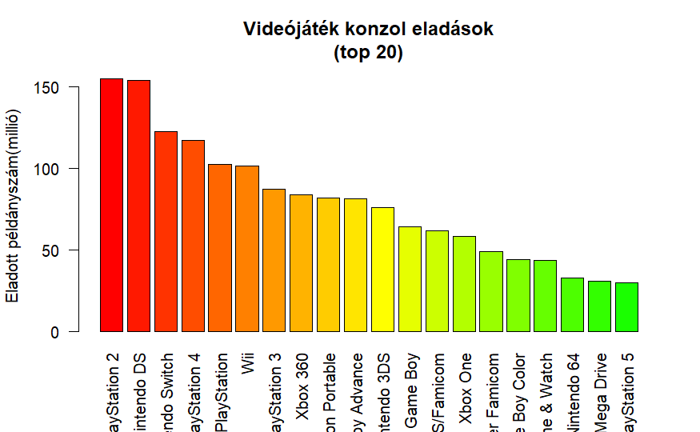

```r
barplot(df$Units.Sold[c(1:20)], names.arg = df$Console.Name[c(1:20)], las=2, col = rainbow(60),
        main ='Videójáték konzol eladások\n(top 20)',
        ylab = 'Eladott példányszám(millió)')
```

Ezen az ábrán a top 20 eladással rendelkező konzol látható. Innen is könnyedén leolvasható, hogy a Playstation 2 mindenidők legtöbbet eladott konzolja, de a Nintendo DS sem marad el sokkal ettől. A 20. helyen található Playstation 5 egy nagyon szép eredmény úgy, hogy csak pár éve jelent meg ez a konzol.

## legtöbbet eladott konzol

```r
df[which(max(df$Units.Sold)== df$Units.Sold),]
```

[output not shown]

## legkevesebbet eladott konzolok

A legtöbbet konzolt már említettem, de nézzük meg a lista végét is. Itt kb 1 milliós példányszémban elkelt konzolokból több is van. Ezek jellemzően a 80-as és a 90es években bemutatott Atari, Philips konzolok.

```r
df[which(min(df$Units.Sold)== df$Units.Sold),]
```

|  | Console.Name | Type | Company | Released.Year | Discontinuation.Year | Units.Sold | Remarks | decade |
| --- | --- | --- | --- | --- | --- | --- | --- | --- |
| 47 | Atari 7800 | Home | Atari | 1986 | 1991 | 1 | Final sales are greater than 1 million | 1980 |
| 48 | Atari Lynx | Handheld | Atari | 1989 | 1995 | 1 | Final sales are greater than 1 million | 1980 |
| 49 | Philips CD-i | Home | Philips | 1990 | 1998 | 1 | Final sales are greater than 1 million | 1990 |
| 50 | Telstar | Dedicated | Coleco | 1976 | 1978 | 1 | Final sales are greater than 1 million | 1970 |
| 51 | Atari 5200 | Home | Atari | 1982 | 1984 | 1 | Final sales are greater than 1 million | 1980 |

```r
companies <- aggregate(df$Units.Sold, by=list(df$Company), FUN=sum)
companies <- companies[order(companies$x,decreasing = T), ]
names(companies)[1:2] <- c('companies', 'units_sold')
total_units <- sum(companies$units_sold)
companies['market_share'] <- sapply(companies$units_sold, function(x) round(x/total_units*100))
```

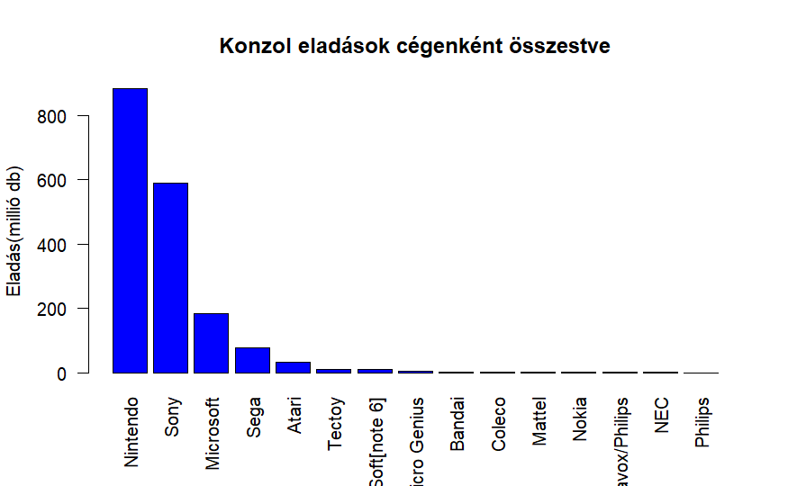

```r
barplot(companies$units_sold, names.arg = companies$companies, las = 2, col = 'blue',
        main = 'Konzol eladások cégenként összestve',
        ylab = 'Eladás(millió db)')
```

A konzol eladásokat cégenként összesítve jól látható, hogy a nintedo termékei kimagaslóan jól fogytak az évek során, utána következik a sony és a microsoft. ez talán nem is meglepő, ez a 3 cég akik a mai napig is gyártanak konzolokat, így a köztudatban is ezek a legismertebb cégek.

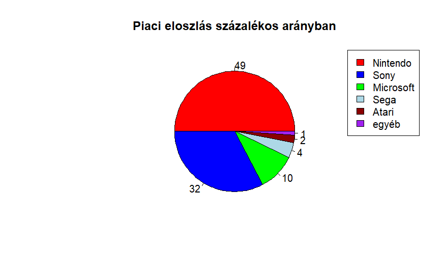

```r
pie(companies$market_share[1:6], companies$market_share,
    col = c('red', 'blue','green','lightblue', 'darkred','purple'),
    main = 'Piaci eloszlás százalékos arányban'
    )
legend("topright", legend = c(companies$companies[1:5],'egyéb'),
       fill = c('red', 'blue','green','lightblue', 'darkred','purple'))
```

Itt százalékos arányban is látható a nintendo fölénye, majdnem a piac felét uralják, a Sony 32, míg a microsoft 10%- os piaci részesedéssel büszkélkedhet.A többi gyártó az 5%-ot sem éri el.

```r
par(mfrow=c(2,2))
barplot(df$Units.Sold[df$decade == 1990][1:5], names.arg = df$Console.Name[df$decade == 1990][1:5], las = 2,
        main= '1990',
        col = c('blue','red', 'red','red', 'lightblue')
        ,ylab = 'Eladott példányszám(millió)')
barplot(df$Units.Sold[df$decade == 2000][1:5], names.arg = df$Console.Name[df$decade == 2000][1:5], las = 2,
        main= '2000',
        col = c('blue','red','red','blue','green'))
```

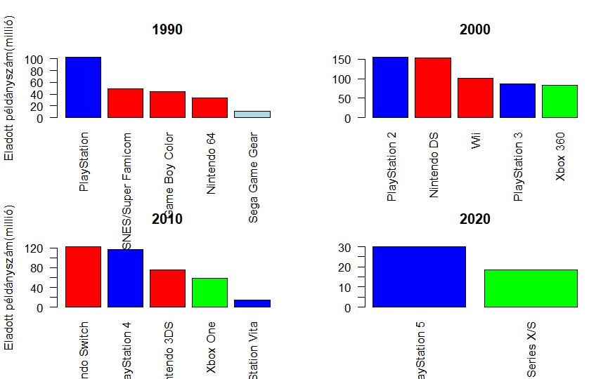

```r
barplot(df$Units.Sold[df$decade == 2010][1:5], names.arg = df$Console.Name[df$decade == 2010][1:5], las = 2,
        main= '2010',
        col = c('red','blue','red','green','blue')
        ,ylab = 'Eladott példányszám(millió)')
barplot(df$Units.Sold[df$decade == 2020][1:2], names.arg = df$Console.Name[df$decade == 2020][1:2], las = 2,
        main= '2020',
        col = c('blue','green'))
```

Az utolsó ábrán évtizedenkénti bontásban hasonlíthatóak össze a konzol eladások. A 90-es években a playstation 1 vitte a prímet 100 millió feletti eladott példánnyal, de a Nintendo 3 különböző konzollal is bekerült a top 5-be ebben az időszakban. A 2000-es években a Nintedno Ds és a Ps 2 eladásai nagyon hasonló számokat hoztak, kb 150 millió eladott példánnyal, de ebben az évtizedben már a microsoft is megjelent a top 5-ben az Xbox 360-al. A 2010-es évek is a Sony és a nintendo között döltek el, de itt a Nintendo Switch lett a befutó a ps4 elött. A 2020-as években, azaz a mostani konzolgenerációban, már csak 2 versenyző jelenik meg, a ps5 és az xbox series x és series s. Bár a nintedo switchet is ide lehetne még sorolni, mert még mindig forgalomban van, nem lenne fair az összehasonlítás mivel az már 2017 óta kapható.